# HOTEL BOOKING PATTERNS AND CANCELLATION ANALYSIS DATASET

```python
import pandas as pd
```

```python
df=pd.read_csv(r"Hotel Reservations.csv")
```

## How do the number of adults/children or room type preferences correlate with booking cancellations?

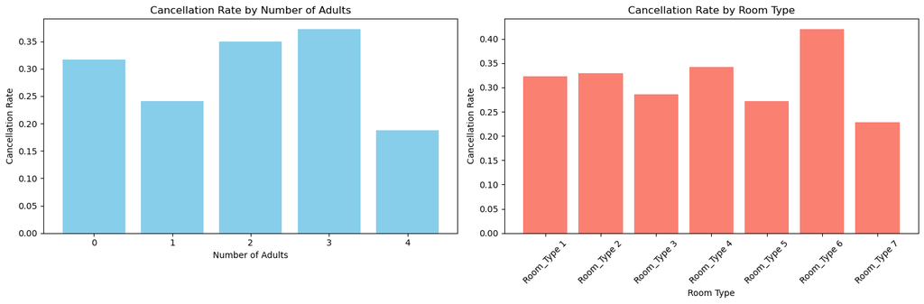

```python
import pandas as pd
import matplotlib.pyplot as plt

# Load data
df = pd.read_csv(r"Hotel Reservations.csv")

# Create a binary cancellation column
df['is_canceled'] = df['booking_status'].map({'Canceled': 1, 'Not_Canceled': 0})

# 1. Cancellation rate by number of adults
adult_cancel = df.groupby('no_of_adults')['is_canceled'].mean().reset_index()

# 2. Cancellation rate by room type
room_cancel = df.groupby('room_type_reserved')['is_canceled'].mean().reset_index()

# Visualizations
plt.figure(figsize=(15, 5))

# Bar chart: Adults vs. cancellation rate
plt.subplot(1, 2, 1)
plt.bar(adult_cancel['no_of_adults'], adult_cancel['is_canceled'], color='skyblue')
plt.title('Cancellation Rate by Number of Adults')
plt.xlabel('Number of Adults')
plt.ylabel('Cancellation Rate')
plt.xticks(adult_cancel['no_of_adults'])

# Bar chart: Room type vs. cancellation rate
plt.subplot(1, 2, 2)
plt.bar(room_cancel['room_type_reserved'], room_cancel['is_canceled'], color='salmon')
plt.title('Cancellation Rate by Room Type')
plt.xlabel('Room Type')
plt.ylabel('Cancellation Rate')
plt.xticks(rotation=45)

plt.tight_layout()
plt.savefig("Cancellation Rate by Number of Adults.png")
plt.show()
```

## Are repeated guests less likely to cancel reservations compared to first-time guests?

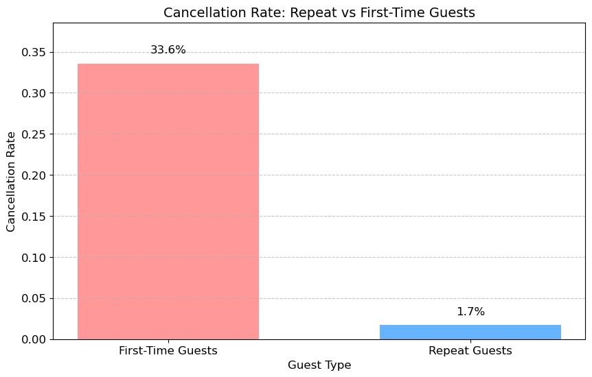

```python
import pandas as pd
import matplotlib.pyplot as plt

# Load data
df = pd.read_csv(r"Hotel Reservations.csv")
df['is_canceled'] = df['booking_status'].map({'Canceled': 1, 'Not_Canceled': 0})

# Group by repeated guests
repeat_cancel = df.groupby('repeated_guest')['is_canceled'].mean().reset_index()

# Visualization (improved)
plt.figure(figsize=(10, 6))

# Create bars with labels
bars = plt.bar(repeat_cancel['repeated_guest'],
              repeat_cancel['is_canceled'],
              color=['#ff9999', '#66b3ff'],
              width=0.6)

# Add value labels on top of bars
for bar in bars:
    height = bar.get_height()
    plt.text(bar.get_x() + bar.get_width()/2,
             height + 0.01,  # Offset for readability
             f'{height:.1%}',
             ha='center',
             va='bottom',
             fontsize=12)

# Formatting improvements
plt.title('Cancellation Rate: Repeat vs First-Time Guests', fontsize=14)
plt.xlabel('Guest Type', fontsize=12)
plt.ylabel('Cancellation Rate', fontsize=12)
plt.xticks([0, 1], ['First-Time Guests', 'Repeat Guests'], fontsize=12)
plt.yticks(fontsize=12)
plt.ylim(0, repeat_cancel['is_canceled'].max() + 0.05)  # Add headroom
plt.grid(axis='y', linestyle='--', alpha=0.7)

# Save with proper filename and settings
plt.savefig("cancellation_rate_repeat_guests.png",
           dpi=300,
           bbox_inches='tight',
           transparent=True)

plt.show()
```

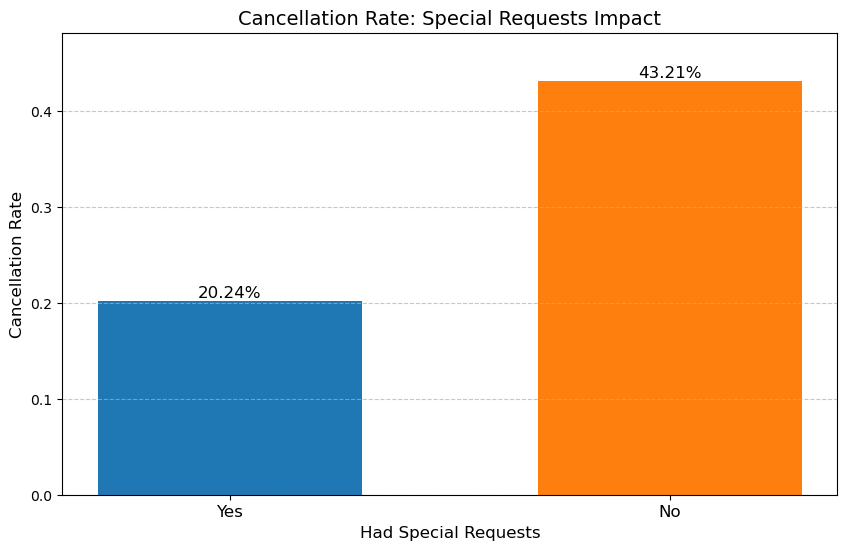

```python
# Categorize bookings with/without special requests
df['has_special_request'] = df['no_of_special_requests'].apply(lambda x: 'Yes' if x > 0 else 'No')
special_cancel = df.groupby('has_special_request')['is_canceled'].mean().reset_index()

# Visualization (Fixed)
plt.figure(figsize=(10, 6))

# Order the categories for better comparison
order = ['Yes', 'No']  # Show "With Requests" first
special_cancel = special_cancel.set_index('has_special_request').loc[order].reset_index()

# Create bar plot with custom styling
bars = plt.bar(special_cancel['has_special_request'],
               special_cancel['is_canceled'],
               color=['#1f77b4', '#ff7f0e'],  # More contrasting colors
               width=0.6)

# Add value labels on top of bars
for bar in bars:
    height = bar.get_height()
    plt.text(bar.get_x() + bar.get_width()/2, height,
             f'{height:.2%}',  # Format as percentage
             ha='center',
             va='bottom',
             fontsize=12)

# Formatting
plt.title('Cancellation Rate: Special Requests Impact', fontsize=14)
plt.xlabel('Had Special Requests', fontsize=12)
plt.ylabel('Cancellation Rate', fontsize=12)
plt.ylim(0, special_cancel['is_canceled'].max() + 0.05)  # Add headroom
plt.xticks(fontsize=12)
plt.grid(axis='y', linestyle='--', alpha=0.7)

# Save and show
plt.savefig("cancellation_rate_special_requests.png",  # Fixed filename
            dpi=300,
            bbox_inches='tight',
            transparent=True)
plt.show()
```

## Is there a relationship between the average price per room and the likelihood of cancellation?

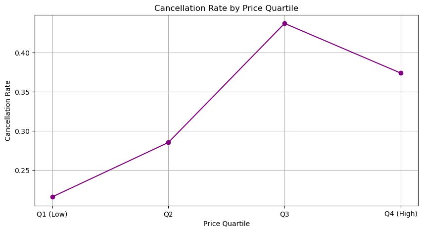

```python
# Bin prices into quartiles
df['price_quartile'] = pd.qcut(df['avg_price_per_room'], q=4, labels=['Q1 (Low)', 'Q2', 'Q3', 'Q4 (High)'])
price_cancel = df.groupby('price_quartile',observed=True)['is_canceled'].mean().reset_index()

# Visualization
plt.figure(figsize=(10, 5))
plt.plot(price_cancel['price_quartile'], price_cancel['is_canceled'], marker='o', color='purple')
plt.title('Cancellation Rate by Price Quartile')
plt.xlabel('Price Quartile')
plt.ylabel('Cancellation Rate')
plt.grid(True)
plt.savefig("Cancellation Rate by Price Quartile.png")
plt.show()
```

## How do cancellations impact revenue, and which room types or market segments contribute most to revenue loss?

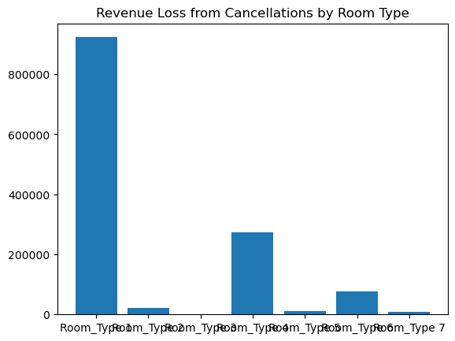

```python
# Example for Question 5 (Revenue loss by room type):
revenue_loss = df[df['is_canceled'] == 1].groupby('room_type_reserved')['avg_price_per_room'].sum()
plt.bar(revenue_loss.index, revenue_loss.values)
plt.title('Revenue Loss from Cancellations by Room Type')
plt.savefig("Revenue Loss from Cancellations by Room Type.png")
plt.show()
```

## Do bookings with meal plans (e.g., "Meal Plan 1") exhibit different cancellation patterns compared to those without

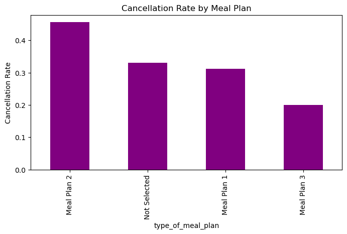

```python
meal_cancel = df.groupby('type_of_meal_plan')['is_canceled'].mean().sort_values(ascending=False)

# Bar chart
plt.figure(figsize=(8, 4))
meal_cancel.plot(kind='bar', color='purple')
plt.title('Cancellation Rate by Meal Plan')
plt.ylabel('Cancellation Rate')
plt.savefig("Cancellation Rate by Meal Plan.png")
plt.show()
```

## How does the lead time (days between booking and arrival) influence cancellation rates?

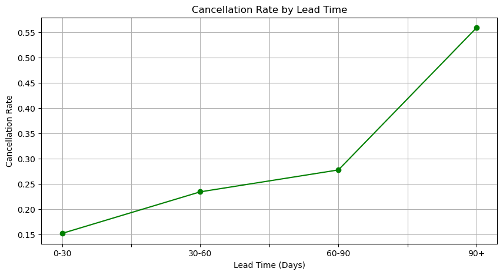

```python
# Bin lead time into categories
df['lead_time_bin'] = pd.cut(df['lead_time'], bins=[0, 30, 60, 90, 365], labels=['0-30', '30-60', '60-90', '90+'])
lead_cancel = df.groupby('lead_time_bin',observed=True)['is_canceled'].mean()

# Line chart
plt.figure(figsize=(10, 5))
lead_cancel.plot(kind='line', marker='o', color='green')
plt.title('Cancellation Rate by Lead Time')
plt.xlabel('Lead Time (Days)')
plt.ylabel('Cancellation Rate')
plt.grid(True)
plt.savefig("Cancellation Rate by Lead Time.png")
plt.show()
```

## Are there specific months or seasons with significantly higher cancellation rates?

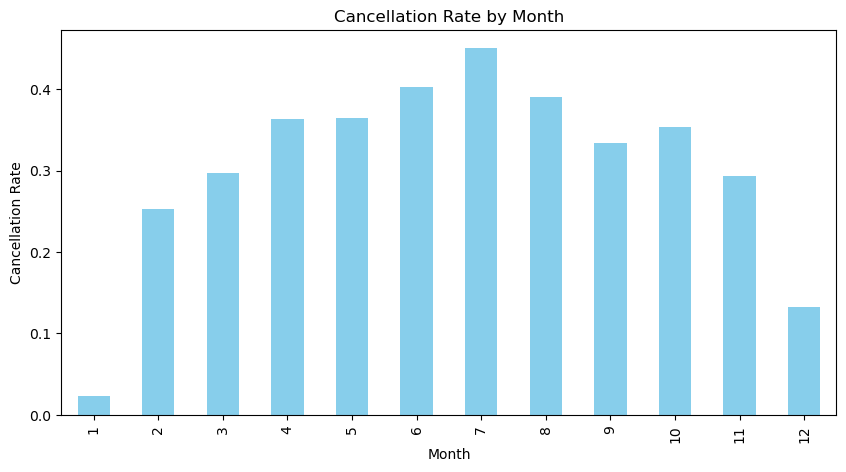

```python
monthly_cancel = df.groupby('arrival_month')['is_canceled'].mean()

# Bar chart
plt.figure(figsize=(10, 5))
monthly_cancel.plot(kind='bar', color='skyblue')
plt.title('Cancellation Rate by Month')
plt.xlabel('Month')
plt.ylabel('Cancellation Rate')
plt.savefig("Cancellation Rate by Month.png")
plt.show()
```

## Do weekend vs. weekday stays affect cancellation behavior differently?

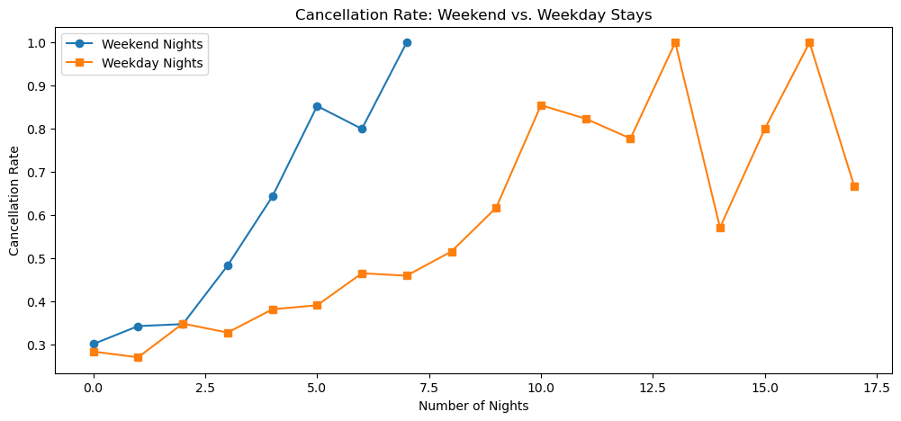

```python
weekend_cancel = df.groupby('no_of_weekend_nights')['is_canceled'].mean()
weekday_cancel = df.groupby('no_of_week_nights')['is_canceled'].mean()

# Line chart
plt.figure(figsize=(12, 5))
plt.plot(weekend_cancel.index, weekend_cancel.values, label='Weekend Nights', marker='o')
plt.plot(weekday_cancel.index, weekday_cancel.values, label='Weekday Nights', marker='s')
plt.title('Cancellation Rate: Weekend vs. Weekday Stays')
plt.xlabel('Number of Nights')
plt.ylabel('Cancellation Rate')
plt.legend()
plt.savefig("Weekend vs. Weekday Stays.png")
plt.show()
```

## How does the requirement for car parking spaces correlate with booking stability or cancellations?

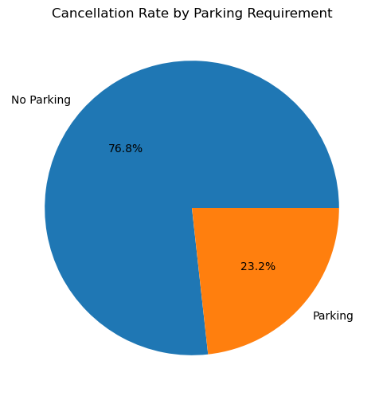

```python
parking_cancel = df.groupby('required_car_parking_space')['is_canceled'].mean()

# Pie chart
plt.figure(figsize=(6, 6))
parking_cancel.plot(kind='pie', autopct='%1.1f%%', labels=['No Parking', 'Parking'])
plt.title('Cancellation Rate by Parking Requirement')
plt.ylabel('')
plt.savefig("Cancellation Rate by Parking Requirement.png")
plt.show()
```

## Which market segments (e.g., Online, Corporate, Aviation) have the highest cancellation rates, and why?

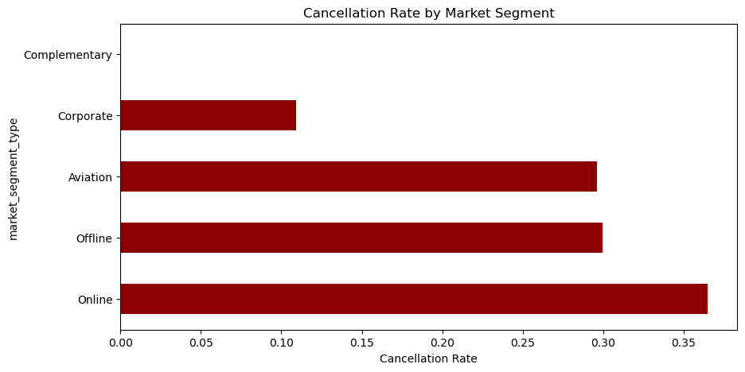

```python
segment_cancel = df.groupby('market_segment_type')['is_canceled'].mean().sort_values(ascending=False)

# Horizontal bar chart
plt.figure(figsize=(10, 5))
segment_cancel.plot(kind='barh', color='darkred')
plt.title('Cancellation Rate by Market Segment')
plt.xlabel('Cancellation Rate')
plt.savefig("Cancellation Rate by Market Segment.png")
plt.show()
```

## Can historical cancellation patterns inform overbooking strategies to optimize occupancy rates?

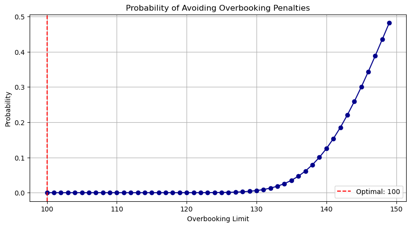

[output not shown]

```python
import pandas as pd
import numpy as np
import matplotlib.pyplot as plt
from scipy.stats import binom

# Load data and define 'is_canceled'
df = pd.read_csv(r"Hotel Reservations.csv")
df['is_canceled'] = df['booking_status'].map({'Canceled': 1, 'Not_Canceled': 0})

# Calculate historical cancellation rate
cancel_rate = df['is_canceled'].mean()

# Simulate overbooking for 100 bookings
base_capacity = 100  # Assume 100 rooms are available
overbook_range = np.arange(100, 150)  # Test overbooking from 100 to 150 rooms

# Calculate probability of cancellations <= overbooking buffer
probabilities = [1 - binom.cdf(base_capacity, bookings, 1 - cancel_rate)
                 for bookings in overbook_range]

# Find optimal limit (e.g., 95% confidence)
optimal_idx = np.argmax(np.array(probabilities) >= 0.95)
optimal_limit = overbook_range[optimal_idx]

# Visualization
plt.figure(figsize=(10, 5))
plt.plot(overbook_range, probabilities, marker='o', color='darkblue')
plt.axvline(optimal_limit, color='red', linestyle='--', label=f'Optimal: {optimal_limit}')
plt.title('Probability of Avoiding Overbooking Penalties')
plt.xlabel('Overbooking Limit')
plt.ylabel('Probability')
plt.legend()
plt.grid(True)
plt.savefig("Probability of Avoiding Overbooking Penalties.png")
plt.show()

print(f"Optimal overbooking limit (95% confidence): {optimal_limit} rooms")
```

## What are the top three predictors of booking cancellations based on this dataset (e.g., lead time, price, room type)?

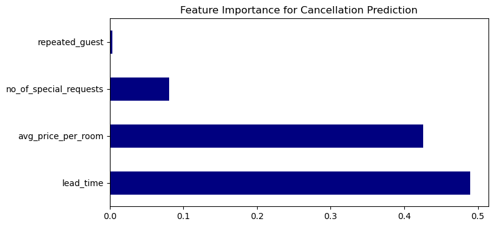

```python
from sklearn.ensemble import RandomForestClassifier

# Prepare data
X = df[['lead_time', 'avg_price_per_room', 'no_of_special_requests', 'repeated_guest']]
y = df['is_canceled']

# Train model
model = RandomForestClassifier()
model.fit(X, y)

# Plot feature importance
plt.figure(figsize=(8, 4))
pd.Series(model.feature_importances_, index=X.columns).plot(kind='barh', color='navy')
plt.title('Feature Importance for Cancellation Prediction')
plt.savefig("Cancellation Prediction.png")
plt.show()
```

## How accurate is a machine learning model trained on this data at predicting cancellations, and which features are most influential?

```
Model Accuracy: 85.72%

              precision    recall  f1-score   support

           0       0.88      0.91      0.89      4839
           1       0.81      0.75      0.78      2416

    accuracy                           0.86      7255
   macro avg       0.84      0.83      0.84      7255
weighted avg       0.86      0.86      0.86      7255
```

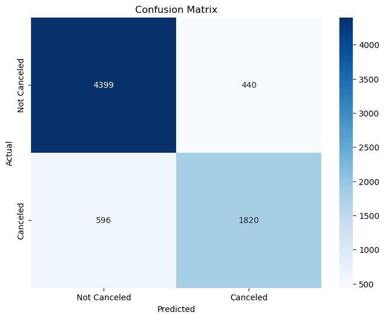

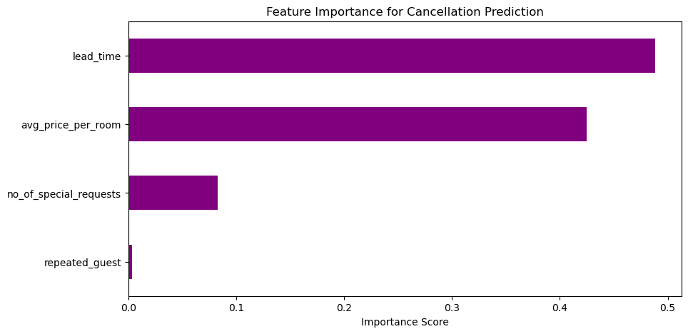

```python
import pandas as pd
import matplotlib.pyplot as plt
import seaborn as sns
from sklearn.model_selection import train_test_split
from sklearn.ensemble import RandomForestClassifier
from sklearn.metrics import accuracy_score, confusion_matrix, classification_report

# Load data and preprocess
df = pd.read_csv(r"Hotel Reservations.csv")
df['is_canceled'] = df['booking_status'].map({'Canceled': 1, 'Not_Canceled': 0})

# Define features and target
features = ['lead_time', 'avg_price_per_room', 'no_of_special_requests', 'repeated_guest']
X = df[features]
y = df['is_canceled']

# Split data into train/test sets
X_train, X_test, y_train, y_test = train_test_split(X, y, test_size=0.2, random_state=42)

# Train the model
model = RandomForestClassifier(random_state=42)
model.fit(X_train, y_train)

# Predictions
y_pred = model.predict(X_test)

# Calculate accuracy
accuracy = accuracy_score(y_test, y_pred)
print(f"Model Accuracy: {accuracy:.2%}\n")
print(classification_report(y_test, y_pred))

# Plot 1: Confusion Matrix
plt.figure(figsize=(8, 6))
cm = confusion_matrix(y_test, y_pred)
sns.heatmap(cm, annot=True, fmt='d', cmap='Blues',
            xticklabels=['Not Canceled', 'Canceled'],
            yticklabels=['Not Canceled', 'Canceled'])
plt.title('Confusion Matrix')
plt.xlabel('Predicted')
plt.ylabel('Actual')
plt.savefig("Confusion Matrix.png")
plt.show()

# Plot 2: Feature Importance
feature_importance = pd.Series(model.feature_importances_, index=features).sort_values(ascending=True)
plt.figure(figsize=(10, 5))
feature_importance.plot(kind='barh', color='purple')
plt.title('Feature Importance for Cancellation Prediction')
plt.xlabel('Importance Score')
plt.savefig("Feature Importance for Cancellation Prediction.png")
plt.show()
```

## Do guests with previous cancellations or no-shows exhibit recurring patterns in new bookings?

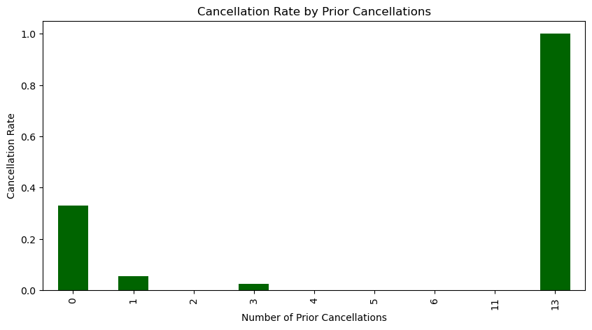

```python
prior_cancel = df.groupby('no_of_previous_cancellations')['is_canceled'].mean()

# Bar chart
plt.figure(figsize=(10, 5))
prior_cancel.plot(kind='bar', color='darkgreen')
plt.title('Cancellation Rate by Prior Cancellations')
plt.xlabel('Number of Prior Cancellations')
plt.ylabel('Cancellation Rate')
plt.savefig("Cancellation Rate by Prior Cancellations.png")
plt.show()
```